# Simultaneous Labs

Adam Dziorny

November 22, 2017

## Contents

This document looks at lab values that appear simultaneously (or near-simultaneously) and analyzes patterns in this data.

1. Loading Data : Loads libraries and data files
2. Verification
3. Analysis
- Analysis Functions
- Gas & Electrolyte Panel Matchup
  - Sodium
  - Potassium
- Hemoglobin Matchup
  - Mismatch Covariates
- iStat & CBC Matchup

All work is (c) Adam Dziorny, 2017.

### Load the Data

First we load the required libraries:

```r
library(dplyr)
library(ggplot2)
library(knitr)
library(ggpubr)
library(cowplot)
library(kableExtra)
library(BlandAltmanLeh)
```

And the full pre-processed dataset:

```r
load('D_preprocessed')
```

### Verification

We need to use the Specimen Taken Date instead of the Result Date. Let’s confirm first that the Specimen Taken Date and the Result Date for `hgb` bases are reasonably close - they should not be very far apart:

```r
date.diff <-
  labs.df %>%
  dplyr::filter(BASE_NM %in% c('hgb')) %>%
  dplyr::mutate(HRS_DIFF = as.numeric(RSLT_DT - SPECIMEN_TAKEN_DT, units = 'hours'))

summary(date.diff$HRS_DIFF)
```

```
##     Min.  1st Qu.   Median     Mean  3rd Qu.     Max.     NA's
##    -23.9      0.2      0.3      2.2      0.6 340778.0        3
```

There are a few errors here, for items that don’t pass the ‘sniff test’. First of all, there should be no negative values - labs cannot result before they are taken. Let’s see how many negative values there are:

```r
cat(sprintf('Number < 0: %0.f\nTotal Number: %0.f\nPercent: %0.4f %%\n',
            sum(date.diff$HRS_DIFF < 0, na.rm = T),
            sum(!is.na(date.diff$HRS_DIFF)),
            sum(date.diff$HRS_DIFF < 0, na.rm = T) / sum(!is.na(date.diff$HRS_DIFF))))
```

```
## Number < 0: 695
## Total Number: 297360
## Percent: 0.0023 %
```

Clearly not a huge percentage, and because `SPECIMEN_TAKEN_DT` relies on human interaction, we assume this is human error. What is the average number of hours before zero?

```r
summary(date.diff$HRS_DIFF[date.diff$HRS_DIFF < 0])
```

```
##      Min.   1st Qu.    Median      Mean   3rd Qu.      Max.      NA's
## -23.90000  -0.73333  -0.13333  -1.20914  -0.05000  -0.01667         3
```

Most of them are right at the zero mark, with only a few (< 25%) falling about a day before - likely the result of either the collector or lab entering the wrong date on the specimen. The result date is the date to believe.

Now we look at the excessive values - the values > 2 hrs and the values > 25 hrs, for example:

```r
cat(sprintf('Number with diff > 2 hours: %0.f\nNumber with diff > 25 hrs: %0.f\n',
            sum(date.diff$HRS_DIFF > 2, na.rm = T),
            sum(date.diff$HRS_DIFF > 25, na.rm = T)))
```

```
## Number with diff > 2 hours: 15386
## Number with diff > 25 hrs: 968
```

Among those with date differences > 25 hours:

```r
summary(date.diff$HRS_DIFF[date.diff$HRS_DIFF > 25])
```

```
##     Min.  1st Qu.   Median     Mean  3rd Qu.     Max.     NA's
##     25.0     31.8     45.9    427.4     77.0 340778.0        3
```

```r
head(sort(date.diff$HRS_DIFF, decreasing = T), n=100)
```

```
##   [1] 340777.9833   8040.8500    744.2000    563.2500    544.4667
##   [6]    521.5667    458.1167    448.7167    447.7167    396.1500
##  [11]    373.7667    367.4833    342.0000    269.0833    245.3500
##  [16]    225.9667    216.4500    215.8333    211.3500    203.2500
##  [21]    203.1833    199.9000    199.2000    196.7000    192.7667
##  [26]    192.7500    192.3500    191.8833    184.9833    182.0000
##  [31]    180.7833    180.3000    180.2167    179.1833    179.1833
##  [36]    178.6333    174.0000    171.5333    170.1500    169.4167
##  [41]    168.8833    168.5167    167.0833    166.2833    162.8333
##  [46]    160.7500    158.0500    157.9833    157.7333    157.6833
##  [51]    157.5333    157.2833    157.2333    156.9000    155.7500
##  [56]    155.3833    155.1833    154.6833    151.9167    151.6667
##  [61]    150.8167    149.8000    149.5167    149.5167    149.3167
##  [66]    149.2833    148.3167    148.3167    148.2833    148.2833
##  [71]    147.6000    147.1500    147.1500    146.9333    146.7667
##  [76]    146.1667    145.5000    145.4667    145.3167    145.0500
##  [81]    144.8500    144.8167    144.5500    144.0167    143.8833
##  [86]    143.7500    143.0833    142.7833    142.5833    141.1833
##  [91]    140.3167    140.3167    139.2667    138.3833    137.9667
##  [96]    137.9167    137.3833    136.6000    136.4667    135.1833
```

Because we are comparing labs of the same `SPECIMEN_TAKEN_DT`, we need not worry about these transcription errors - if anything, they will decrease our *simultaneously collected* sample size if different labs have different `SPECIMEN_TAKEN_DT` values. However, to better view the histogram we are going to eliminate date differences > 120 hours.

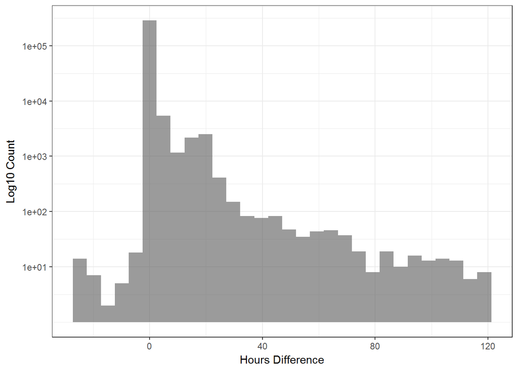

```r
date.diff %>%
  dplyr::filter(HRS_DIFF < 120) %>%
  #dplyr::mutate(IS_NEG = if_else(HRS_DIFF < 0,'p','c')) %>%
  ggplot() +
  geom_histogram(aes(x = HRS_DIFF), alpha = 0.6, bins = 30) +
  scale_y_log10(breaks = c(1e1,1e2,1e3,1e4,1e5,1e6)) +
  scale_fill_manual(name = 'Is Negative?',
                    values = c('p'='red','c'='blue'),
                    labels = c('p' = 'Yes','c' = 'No')) +
  ylab('Log10 Count') +
  xlab('Hours Difference') +
  labs(fill = 'Is Negative') +
  theme_bw()
```

### Analysis

Now we begin to analyze the simultaneously-collected labs. The basic framework for this analysis is to select the labs from the different PROCEDUREs, join the two based on `VISIT_KEY` and `SPECIMEN_TAKEN_DT`, and then display and analyze.

The outcomes we desire for this section are the Pearson Correlation Coefficient and the Bland-Altman method of comparison. Specifically, for each location (CICU vs PICU) we are interested in the following:

- Values:
- Pearson correlation coefficient statistics (R, R^2 and p-value)
- Bland-Altman mean bias, upper and lower limits
- Plots:
- Scatter plot
- Bland Altman plot

We will first develop the functions to compute these for lists of procedures (and a given `BASE_NM`).

#### Functions

Function to compute the joined table, based on either an exact time match or a (variable) mismatch:

```r
computeJoinedTable <- function (proc.x, proc.y, base.nm, suffix,
                                cutoff.val = 1000, time.diff = NULL)
{
  df.filt.x <-
    labs.df %>%
    dplyr::filter(PROC_NM %in% proc.x) %>%
    dplyr::filter(BASE_NM %in% base.nm) %>%
    dplyr::filter(VALUE < cutoff.val) %>%
    dplyr::select(VISIT_KEY, PAT_KEY, PROC_ORD_KEY,
                  SPECIMEN_TAKEN_DT, RSLT_DT, DEPT_GRP, VALUE)

  df.filt.y <-
    labs.df %>%
    dplyr::filter(PROC_NM %in% proc.y) %>%
    dplyr::filter(BASE_NM %in% base.nm) %>%
    dplyr::filter(VALUE < cutoff.val) %>%
    dplyr::select(VISIT_KEY, PAT_KEY, PROC_ORD_KEY,
                  SPECIMEN_TAKEN_DT, RSLT_DT, DEPT_GRP, VALUE)

  if (is.null(time.diff)) {
    df.joined <-
      dplyr::inner_join(x = df.filt.x, y = df.filt.y,
                        by = c('VISIT_KEY', 'PAT_KEY', 'SPECIMEN_TAKEN_DT', 'DEPT_GRP'),
                        suffix = suffix) %>%
      dplyr::mutate(RSLT_DIFF_HR = as.numeric(
        get(paste0('RSLT_DT',suffix[1])) - get(paste0('RSLT_DT',suffix[2])), units = 'hours'))
  } else {
    df.joined <-
      dplyr::inner_join(x = df.filt.x, y = df.filt.y,
                        by = c('VISIT_KEY', 'PAT_KEY', 'DEPT_GRP'),
                        suffix = suffix) %>%
      dplyr::mutate(
        RSLT_DIFF_HR = as.numeric(
          get(paste0('RSLT_DT',suffix[1])) - get(paste0('RSLT_DT',suffix[2])), units = 'hours'),
        SPEC_TAKEN_DIFF_MIN = as.numeric(
          get(paste0('SPECIMEN_TAKEN_DT',suffix[1])) - get(paste0('SPECIMEN_TAKEN_DT',suffix[2])), units = 'mins')) %>%
      dplyr::filter(abs(SPEC_TAKEN_DIFF_MIN) < time.diff)
  }

  return(df.joined)
}
```

Function to calculate Pearson Correlation Coefficient data points and plot:

```r
pearsonCalculations <- function (df.joined, suffix, dept.grp, xlab = '', ylab = '',
                                 plot.jitter = T, plot.abline = T, plot.density = T,
                                 print.res = T)
{
  df.filt.joined <-
    df.joined %>%
    dplyr::filter(DEPT_GRP == dept.grp)

  cor.res <-
    cor.test(df.filt.joined[,paste0('VALUE',suffix[1])],
             df.filt.joined[,paste0('VALUE',suffix[2])],
             alternative='two.sided',
             method='pearson')

  res <- list()

  res[[1]] <- cor.res
  res[[2]] <- cor.res$estimate

  plot.res <-
    df.filt.joined %>%
    ggplot()

  if (plot.jitter) {
    plot.res <- plot.res +
      geom_jitter(aes_string(x = paste0('VALUE',suffix[1]), y = paste0('VALUE',suffix[2])), size = 0.2)
  } else {
    plot.res <- plot.res +
      geom_point(aes_string(x = paste0('VALUE',suffix[1]), y = paste0('VALUE',suffix[2])), size = 0.2)
  }

  if (plot.abline) {
    plot.res <- plot.res +
      geom_abline(mapping = NULL, data = NULL,
                  slope = 1, intercept = 0,  na.rm = FALSE, show.legend = NA)
  }

  if (plot.density) {
    plot.res <- plot.res +
      geom_density2d(aes_string(x = paste0('VALUE',suffix[1]),
                                y = paste0('VALUE',suffix[2])),
                     color = 'red', size=1, alpha = 0.5)
  }

  # Calculate the limits on the graph to 0.1% and 99.9% of the data
  q.x <- quantile(df.filt.joined[,paste0('VALUE',suffix[1])], c(0.001,0.999))
  q.y <- quantile(df.filt.joined[,paste0('VALUE',suffix[2])], c(0.001,0.999))

  lim <- c(max(q.x[1],q.y[1]), max(q.x[2],q.y[2]))

  plot.res <- plot.res +
    scale_y_continuous(limits = lim) +
    scale_x_continuous(limits = lim) +
    xlab(xlab) +
    ylab(ylab)

  res[[3]] <- plot.res

  # Optionally, print the results
  if (print.res) {
    cat(sprintf('Correlation: R = %0.3f\nR^2 = %0.4f\n',
                res[[2]],
                res[[2]] * res[[2]]))
  }

  return(res)
}
```

Function to generate Bland Altman plot (otherwise known as Tukey’s Mean Difference Plot) & stats, based on this 1986 publication by JM Bland and DG Altman (found [here](http://www-users.york.ac.uk/~mb55/meas/ba.htm)). We use the package `BlandAltmanLeh` available from CRAN repository (and documented [here](https://cran.r-project.org/web/packages/BlandAltmanLeh/vignettes/Intro.html)) to first make the plot, and second calculate the statistics - namely, the mean difference and 95% confidence intervals. These intervals suggest that 95% of the data fall between these intervals.

```r
blandAltmanCalculate <- function (df.joined, suffix, dept.grp,
                                  xlab = NULL, ylab = NULL,
                                  print.res = T)
{
  # Filter by the DEPT_GRP first
  df.filt.joined <-
    df.joined %>%
    dplyr::filter(DEPT_GRP == dept.grp)

  res <- list()

  # Calculate the stats
  stats <- bland.altman.stats(df.filt.joined[,paste0('VALUE',suffix[1])],
                              df.filt.joined[,paste0('VALUE',suffix[2])])

  res[[1]] <- stats

  res[[2]] <- stats$mean.diffs
  res[[3]] <- stats$lower.limit
  res[[4]] <- stats$upper.limit

  # Generate the plot
  res[[5]] <-
    bland.altman.plot(df.filt.joined[,paste0('VALUE',suffix[1])],
                      df.filt.joined[,paste0('VALUE',suffix[2])],
                      graph.sys='ggplot2')

  if (!is.null(xlab)) {
    res[[5]] <- res[[5]] +
      xlab(xlab)
  }

  if (!is.null(ylab)) {
    res[[5]] <- res[[5]] +
      ylab(ylab)
  }

  # Print the results
  if (print.res) {
    cat(sprintf(paste0(
      'Mean Difference: %0.2f\n',
      'Confidence Interval: %0.2f to %0.2f\n'),
      stats$mean.diffs,
      stats$lower.limit, stats$upper.limit))
  }

  return(res)
}
```

#### Simultaneous Sodium

```r
na.joined <-
  computeJoinedTable(proc.x = c('BMP','CMP'),
                     proc.y = c('VBG-L','sVBG', 'VBG', 'sABG', 'ABG-L', 'ABG'),
                     base.nm = c('na'),
                     suffix = c('.panel', '.gas'))

res.picu <-
  pearsonCalculations(df.joined = na.joined,
                      suffix = c('.panel', '.gas'),
                      dept.grp = c('PICU'),
                      xlab = 'Panel Sodium (mmol/L)',
                      ylab = 'Blood Gas Sodium (mmol/L)',
                      print.res = T)
```

```
## Correlation: R = 0.934
## R^2 = 0.8720
```

```r
res.cicu <-
  pearsonCalculations(df.joined = na.joined,
                      suffix = c('.panel', '.gas'),
                      dept.grp = c('CICU'),
                      xlab = 'Panel Sodium (mmol/L)',
                      ylab = 'Blood Gas Sodium (mmol/L)',
                      print.res = T)
```

```
## Correlation: R = 0.932
## R^2 = 0.8685
```

Plot the scatter plots for both locations:

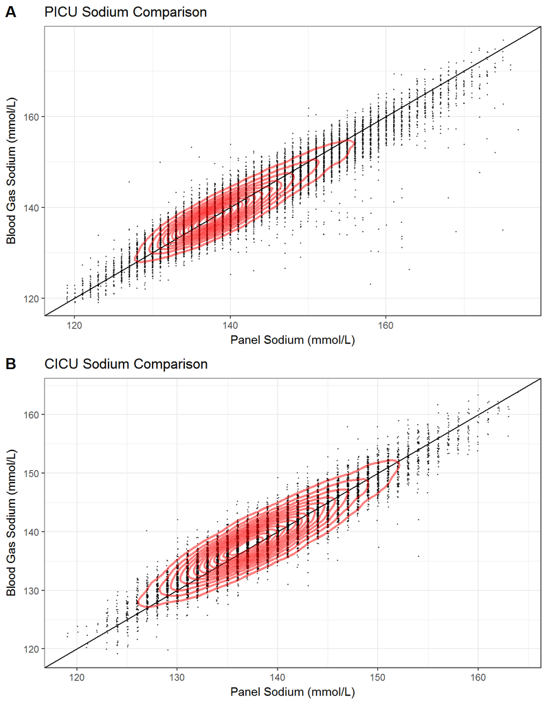

```r
plot_grid(res.picu[[3]] +
            ggtitle('PICU Sodium Comparison') +
            theme_bw(),
          res.cicu[[3]] +
            ggtitle('CICU Sodium Comparison') +
            theme_bw(),
          labels = LETTERS[1:2],
          ncol = 1, nrow = 2)
```

```r
ba.picu <- blandAltmanCalculate(df.joined = na.joined,
                                suffix = c('.panel','.gas'),
                                dept.grp = 'PICU',
                                xlab = 'Average of Panel and Gas Na (mmol/L)',
                                ylab = 'Bias [Panel - Gas Na (mmol/L)]',
                                print.res = T)
```

```
## Mean Difference: 0.37
## Confidence Interval: -4.80 to 5.54
```

```r
ba.cicu <- blandAltmanCalculate(df.joined = na.joined,
                                suffix = c('.panel','.gas'),
                                dept.grp = 'CICU',
                                xlab = 'Average of Panel and Gas Na (mmol/L)',
                                ylab = 'Bias [Panel - Gas Na (mmol/L)]',
                                print.res = T)
```

```
## Mean Difference: -0.37
## Confidence Interval: -4.68 to 3.94
```

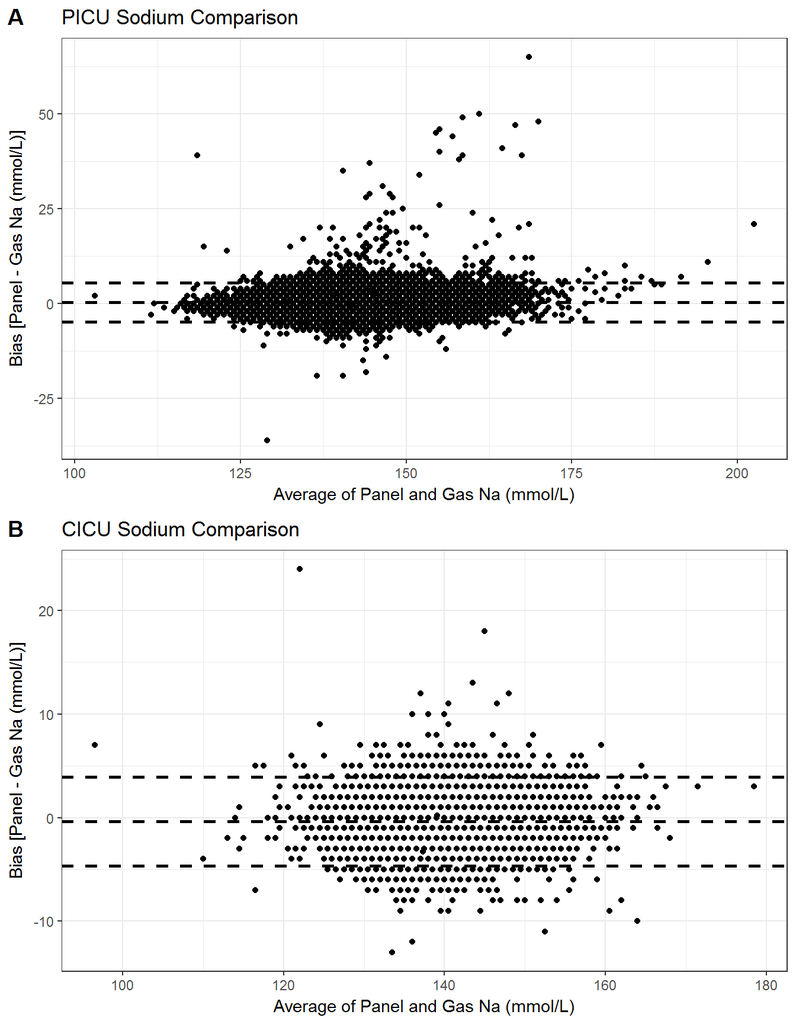

```r
plot_grid(ba.picu[[5]] +
            ggtitle('PICU Sodium Comparison') +
            theme_bw(),
          ba.cicu[[5]] +
            ggtitle('CICU Sodium Comparison') +
            theme_bw(),
          labels = LETTERS[1:2],
          ncol = 1, nrow = 2)
```

#### Simultaneous Potassium

```r
k.joined <-
  computeJoinedTable(proc.x = c('BMP','CMP'),
                     proc.y = c('VBG-L','sVBG', 'VBG', 'sABG', 'ABG-L', 'ABG'),
                     base.nm = c('k'),
                     suffix = c('.panel', '.gas'))

res.picu <-
  pearsonCalculations(df.joined = k.joined,
                      suffix = c('.panel', '.gas'),
                      dept.grp = c('PICU'),
                      xlab = 'Panel Potassium (mmol/L)',
                      ylab = 'Blood Gas Potassium (mmol/L)',
                      print.res = T)
```

```
## Correlation: R = 0.948
## R^2 = 0.8986
```

```r
res.cicu <-
  pearsonCalculations(df.joined = k.joined,
                      suffix = c('.panel', '.gas'),
                      dept.grp = c('CICU'),
                      xlab = 'Panel Potassium (mmol/L)',
                      ylab = 'Blood Gas Potassium (mmol/L)',
                      print.res = T)
```

```
## Correlation: R = 0.926
## R^2 = 0.8570
```

Plot the scatter plots for both locations:

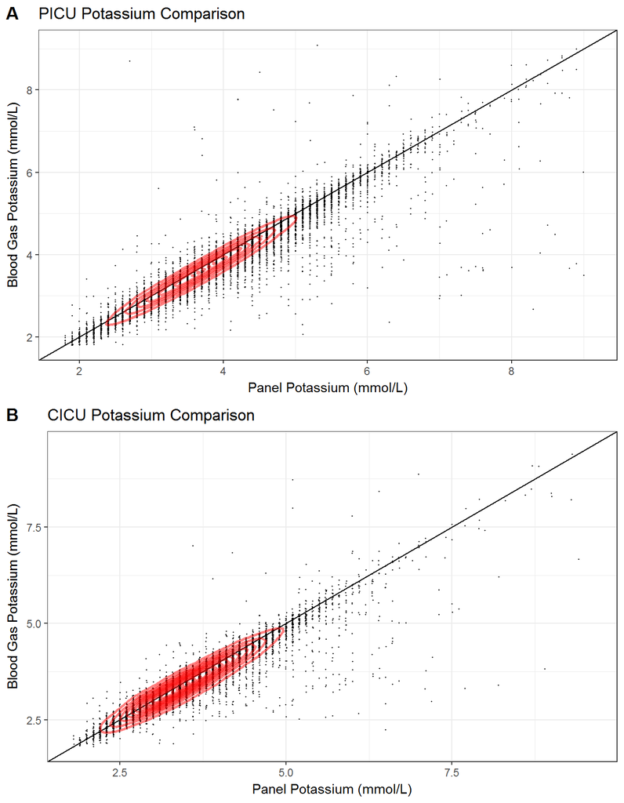

```r
plot_grid(res.picu[[3]] +
            ggtitle('PICU Potassium Comparison') +
            theme_bw(),
          res.cicu[[3]] +
            ggtitle('CICU Potassium Comparison') +
            theme_bw(),
          labels = LETTERS[1:2],
          ncol = 1, nrow = 2)
```

```r
ba.picu <- blandAltmanCalculate(df.joined = k.joined,
                                suffix = c('.panel','.gas'),
                                dept.grp = 'PICU',
                                xlab = 'Average of Panel and Gas Potassium (mmol/L)',
                                ylab = 'Bias [Panel - Gas Potassium (mmol/L)]',
                                print.res = T)
```

```
## Mean Difference: 0.10
## Confidence Interval: -0.40 to 0.60
```

```r
ba.cicu <- blandAltmanCalculate(df.joined = k.joined,
                                suffix = c('.panel','.gas'),
                                dept.grp = 'CICU',
                                xlab = 'Average of Panel and Gas Potassium (mmol/L)',
                                ylab = 'Bias [Panel - Gas Potassium (mmol/L)]',
                                print.res = T)
```

```
## Mean Difference: 0.09
## Confidence Interval: -0.48 to 0.66
```

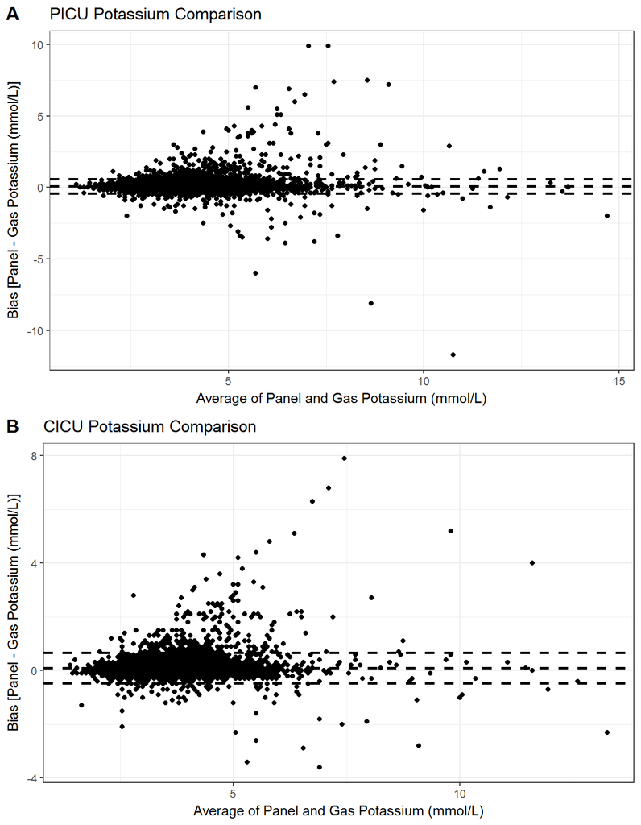

```r
plot_grid(ba.picu[[5]] +
            ggtitle('PICU Potassium Comparison') +
            theme_bw(),
          ba.cicu[[5]] +
            ggtitle('CICU Potassium Comparison') +
            theme_bw(),
          labels = LETTERS[1:2],
          ncol = 1, nrow = 2)
```

#### Simultaneous Hemoglobins

```r
hgb.joined <-
  computeJoinedTable(proc.x = c('CBC w Diff', 'CBC wo Diff'),
                     proc.y = c('VBG-L','sVBG', 'VBG', 'sABG', 'ABG-L', 'ABG'),
                     base.nm = c('hgb'),
                     suffix = c('.cbc', '.gas'))
```

##### Time Differences

Let’s start by looking at the result time difference between the two labs, in hours - first the summary, then the heads of the top and bottom:

```r
summary(hgb.joined$RSLT_DIFF_HR)
```

```
##      Min.   1st Qu.    Median      Mean   3rd Qu.      Max.
## -457.4333    0.2500    0.5500    0.9351    0.8833  563.1000
```

```r
head(sort(hgb.joined$RSLT_DIFF_HR))
```

```
## [1] -457.43333  -81.80000  -56.56667  -52.51667  -49.81667  -48.43333
```

```r
head(sort(hgb.joined$RSLT_DIFF_HR, decreasing = T))
```

```
## [1] 563.1000 211.0667 202.7667 198.8833 191.8500 191.6667
```

How many fall outside the range of -2 to +2 hours:

```r
cat(sprintf('Count outside range: %0.f\nTotal count: %0.f\n',
            sum(hgb.joined$RSLT_DIFF_HR < -2 | hgb.joined$RSLT_DIFF_HR > 2),
            sum(!is.na(hgb.joined$RSLT_DIFF_HR))))
```

```
## Count outside range: 1799
## Total count: 37766
```

##### Simultaneous Values

First we look by department, separating out the PICU and the CICU:

```r
res.picu <-
  pearsonCalculations(df.joined = hgb.joined,
                      suffix = c('.cbc', '.gas'),
                      dept.grp = c('PICU'),
                      xlab = 'CBC Hemoglobin (g/dL)',
                      ylab = 'Blood Gas Hemoglobin (g/dL)',
                      print.res = T)
```

```
## Correlation: R = 0.908
## R^2 = 0.8240
```

```r
res.cicu <-
  pearsonCalculations(df.joined = hgb.joined,
                      suffix = c('.cbc', '.gas'),
                      dept.grp = c('CICU'),
                      xlab = 'CBC Hemoglobin (g/dL)',
                      ylab = 'Blood Gas Hemoglobin (g/dL)',
                      print.res = T)
```

```
## Correlation: R = 0.976
## R^2 = 0.9535
```

Now we look at graphical plots of these two coefficients:

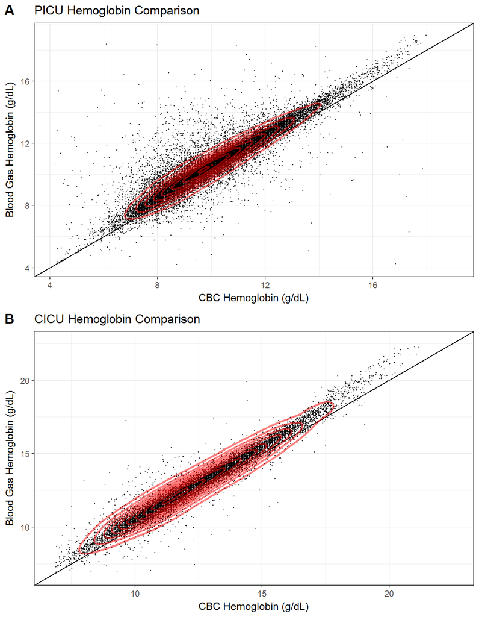

```r
plot_grid(res.picu[[3]] +
            ggtitle('PICU Hemoglobin Comparison') +
            theme_bw(),
          res.cicu[[3]] +
            ggtitle('CICU Hemoglobin Comparison') +
            theme_bw(),
          labels = LETTERS[1:2],
          ncol = 1, nrow = 2)
```

Now we compute the Bland-Altman statistics and plots:

```r
ba.picu <- blandAltmanCalculate(df.joined = hgb.joined,
                                suffix = c('.cbc','.gas'),
                                dept.grp = 'PICU',
                                xlab = 'Average of CBC and Gas HGB (g/dL)',
                                ylab = 'Bias [CBC - Gas Hgb (g/dL)]',
                                print.res = T)
```

```
## Mean Difference: -0.62
## Confidence Interval: -2.23 to 0.98
```

```r
ba.cicu <- blandAltmanCalculate(df.joined = hgb.joined,
                                suffix = c('.cbc','.gas'),
                                dept.grp = 'CICU',
                                xlab = 'Average of CBC and Gas HGB (g/dL)',
                                ylab = 'Bias [CBC - Gas Hgb (g/dL)]',
                                print.res = T)
```

```
## Mean Difference: -0.51
## Confidence Interval: -1.53 to 0.52
```

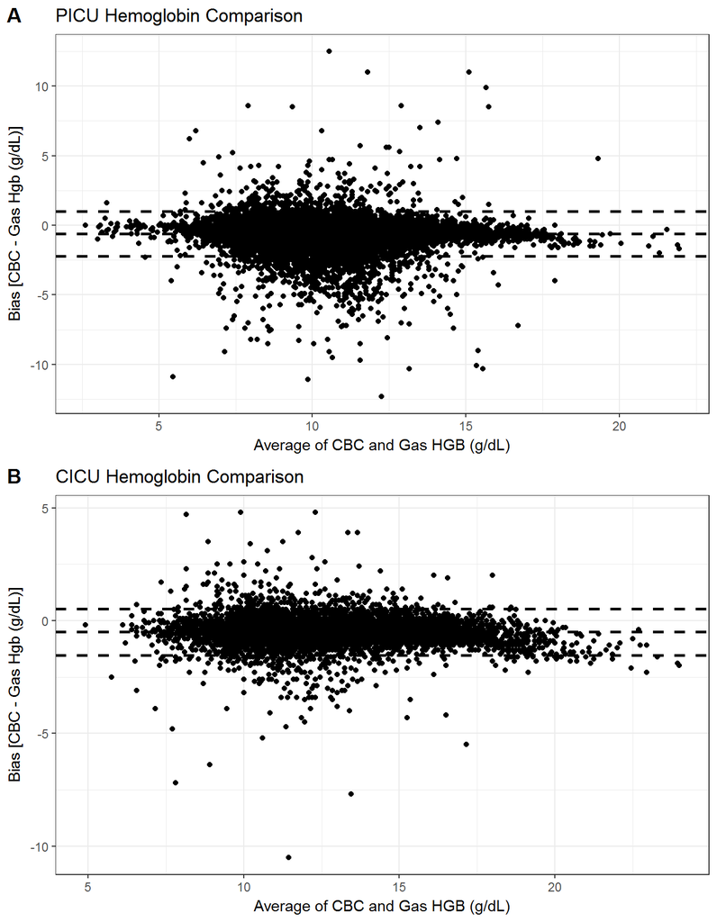

```r
plot_grid(ba.picu[[5]] +
            ggtitle('PICU Hemoglobin Comparison') +
            theme_bw(),
          ba.cicu[[5]] +
            ggtitle('CICU Hemoglobin Comparison') +
            theme_bw(),
          labels = LETTERS[1:2],
          ncol = 1, nrow = 2)
```

> In both cases, the mean difference is less than zero implying that the value of a Blood Gas Hemoglobin tends to run slightly higher than a CBC Hemoglobin. The spread is greater in the PICU than in the CICU, with wider confidence intervals even in the middle section.

##### Mismatch Covariates

We’d like to try and tease out what makes some Hgb match and some mismatched. To do this, let us look at a dichotomous variable `well.matched` which will be `TRUE` if the hemoglobins are well-matched, and `FALSE` if they are not. Then we will look at a few covariates: PAT_SVC, SEX, AGE (Category), WBC, PLT, pH, PO2, BICARB.

```r
cutoff <- 1.5

match.df <-
  hgb.joined %>%
  dplyr::mutate(VALUE_ABS_DIFF = abs(VALUE.cbc - VALUE.gas)) %>%
  dplyr::mutate(WELL_MATCHED = if_else(VALUE_ABS_DIFF < cutoff, 'Yes', 'No'),
                WELL_MATCHED = factor(WELL_MATCHED))

# Show table of well_matched values
table(match.df$WELL_MATCHED)
```

```
##
##    No   Yes
##  2271 35495
```

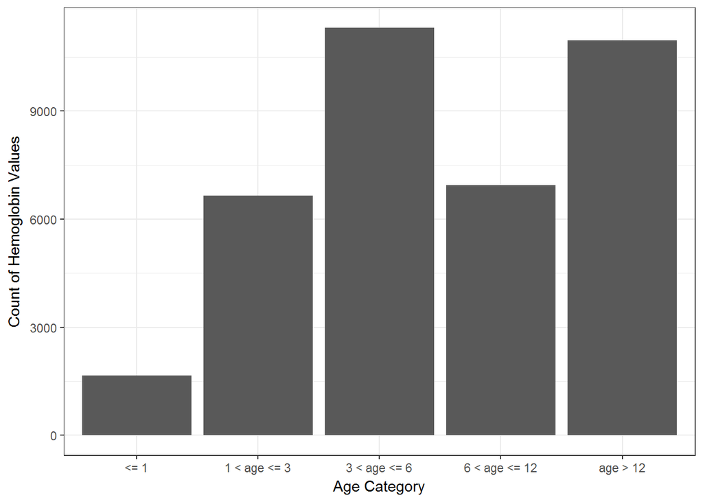

```r
# Join with the `final.cohort` to get demographic info
demo.match.df <-
  dplyr::left_join(x = match.df,
                   y = final.cohort %>%
                     dplyr::group_by(VISIT_KEY, PAT_KEY) %>%
                     dplyr::summarize(PAT_SVC = PAT_SVC[1],
                                      PAT_DOB = PAT_DOB[1],
                                      PAT_SEX = PAT_SEX[1]) %>%
                     dplyr::select(VISIT_KEY, PAT_KEY, PAT_SVC, PAT_DOB, PAT_SEX),
                   by = c('VISIT_KEY', 'PAT_KEY')) %>%
  dplyr::filter(!is.na(PAT_SEX)) %>%
  dplyr::mutate(AGE_AT_TEST = as.numeric(max(RSLT_DT.gas,RSLT_DT.cbc) - PAT_DOB, units='days') / 365.25,
                AGE_CAT = if_else(AGE_AT_TEST <= 1, '<= 1',
                                  if_else(AGE_AT_TEST <= 3, '1 < age <= 3',
                                          if_else(AGE_AT_TEST <= 6, '3 < age <= 6',
                                                  if_else(AGE_AT_TEST <= 12, '6 < age <= 12','age > 12')))),
                AGE_CAT = factor(AGE_CAT),
                MEAN_HGB = (VALUE.cbc + VALUE.gas) / 2)


# Plot count of Hgb values by age category, to show distribution of age categories
demo.match.df %>%
  ggplot() +
  geom_bar(aes(AGE_CAT)) +
  xlab('Age Category') +
  ylab('Count of Hemoglobin Values') +
  theme_bw()
```

```r
# Now we gather the WBC and PLT from the CBC PROC_ORDER_KEY
df.wbc <-
  labs.df %>%
  dplyr::filter(BASE_NM == 'wbc') %>%
  dplyr::group_by(PROC_ORD_KEY) %>%
  dplyr::summarize(WBC = VALUE[1]) %>%
  dplyr::select(PROC_ORD_KEY, WBC)

df.plt <-
  labs.df %>%
  dplyr::filter(BASE_NM == 'plt') %>%
  dplyr::group_by(PROC_ORD_KEY) %>%
  dplyr::summarize(PLT = VALUE[1]) %>%
  dplyr::select(PROC_ORD_KEY, PLT)

df.cbc <-
  full_join(x = df.wbc,
            y = df.plt,
            by = c('PROC_ORD_KEY'))

# Join CBC values
demo.cbc.match.df <-
  dplyr::left_join(x = demo.match.df,
                   y = df.cbc,
                   by = c('PROC_ORD_KEY.cbc' = 'PROC_ORD_KEY'))

# Now pull the unique pH, pO2 and Bicarb values from the gas
df.ph <-
  labs.df %>%
  dplyr::filter(BASE_NM == 'pH') %>%
  dplyr::group_by(PROC_ORD_KEY) %>%
  dplyr::summarize(PH = VALUE[1]) %>%
  dplyr::select(PROC_ORD_KEY, PH)

df.po2 <-
  labs.df %>%
  dplyr::filter(BASE_NM == 'pO2') %>%
  dplyr::group_by(PROC_ORD_KEY) %>%
  dplyr::summarize(PO2 = VALUE[1]) %>%
  dplyr::select(PROC_ORD_KEY, PO2)

df.bicarb <-
  labs.df %>%
  dplyr::filter(BASE_NM == 'bicarb') %>%
  dplyr::group_by(PROC_ORD_KEY) %>%
  dplyr::summarize(BICARB = VALUE[1]) %>%
  dplyr::select(PROC_ORD_KEY, BICARB)

df.gas <-
  full_join(x = df.ph,
            y = df.po2,
            by = c('PROC_ORD_KEY'))

df.gas <-
  full_join(x = df.gas,
            y = df.bicarb,
            by = c('PROC_ORD_KEY'))

# And join `gas` elements to make the final data frame, and filter by invalid values
demo.cbc.gas.match.df <-
  dplyr::left_join(x = demo.cbc.match.df,
                   y = df.gas,
                   by = c('PROC_ORD_KEY.gas' = 'PROC_ORD_KEY')) %>%
  dplyr::filter(WBC < 1000 & PLT < 1000 &
                  !is.na(PH) & PH < 8 &
                  !is.na(PO2) & PO2 < 1000 &
                  !is.na(BICARB) & BICARB < 1000)

# Now we run the GLM on our items of interest
model.logistic <-
  glm((WELL_MATCHED == 'No') ~ MEAN_HGB + PAT_SVC + PAT_SEX + AGE_AT_TEST + WBC + PLT + PH + PO2 + BICARB,
      data = demo.cbc.gas.match.df, family = binomial)

summary(model.logistic)
```

```
##
## Call:
## glm(formula = (WELL_MATCHED == "No") ~ MEAN_HGB + PAT_SVC + PAT_SEX +
##     AGE_AT_TEST + WBC + PLT + PH + PO2 + BICARB, family = binomial,
##     data = demo.cbc.gas.match.df)
##
## Deviance Residuals:
##     Min       1Q   Median       3Q      Max
## -1.4560  -0.3915  -0.3411  -0.2501   3.4687
##
## Coefficients:
##                                         Estimate Std. Error z value
## (Intercept)                           -1.047e+01  2.352e+00  -4.454
## MEAN_HGB                              -8.485e-03  1.142e-02  -0.743
## PAT_SVCAllergy                        -1.215e+01  6.239e+02  -0.019
## PAT_SVCBone Marrow Transplant          5.469e-01  4.460e-01   1.226
## PAT_SVCCardiac Critical Care          -1.272e-01  5.655e-01  -0.225
## PAT_SVCCardiology                     -5.369e-01  4.396e-01  -1.221
## PAT_SVCCardiovascular Radiology       -1.275e+01  8.827e+02  -0.014
## PAT_SVCCardiovascular Surgery         -7.168e-01  4.440e-01  -1.615
## PAT_SVCCritical Care                   1.190e-01  4.319e-01   0.276
## PAT_SVCEmergency                      -5.634e-01  4.859e-01  -1.159
## PAT_SVCEndocrinology                  -1.168e+01  4.380e+02  -0.027
## PAT_SVCGeneral Pediatrics              1.623e-01  4.877e-01   0.333
## PAT_SVCGeneral Surgery                -6.654e-01  4.517e-01  -1.473
## PAT_SVCGI/Nutrition                   -5.838e-01  5.395e-01  -1.082
## PAT_SVCHematology                     -1.884e+00  1.098e+00  -1.715
## PAT_SVCImmunology                     -1.228e+01  2.659e+02  -0.046
## PAT_SVCIntegrated Care Service         1.645e-01  8.531e-01   0.193
## PAT_SVCMetabolism                     -1.182e+01  2.443e+02  -0.048
## PAT_SVCNeonatology                    -8.469e-01  4.841e-01  -1.749
## PAT_SVCNephrology                     -1.393e-01  4.932e-01  -0.282
## PAT_SVCNeurology                       2.009e-01  5.679e-01   0.354
## PAT_SVCNeurosurgery                   -3.373e-01  4.883e-01  -0.691
## PAT_SVCNOT APPLICABLE                 -1.192e+01  3.327e+02  -0.036
## PAT_SVCOncology                        8.537e-01  4.432e-01   1.926
## PAT_SVCOral and Maxillofacial Surgery -1.230e+01  8.827e+02  -0.014
## PAT_SVCOrthopedics                    -3.240e-01  4.724e-01  -0.686
## PAT_SVCOther                          -1.167e+01  2.275e+02  -0.051
## PAT_SVCOtorhinolaryngology            -1.096e-01  6.315e-01  -0.174
```

[output cut: 52 more lines]

```
## WBC                                   0.007648 **
## PLT                                   0.128680
## PH                                    0.000546 ***
## PO2                                   2.53e-08 ***
## BICARB                                0.086279 .
## ---
## Signif. codes:  0 '***' 0.001 '**' 0.01 '*' 0.05 '.' 0.1 ' ' 1
##
## (Dispersion parameter for binomial family taken to be 1)
##
##     Null deviance: 16946  on 37329  degrees of freedom
## Residual deviance: 16358  on 37288  degrees of freedom
## AIC: 16442
##
## Number of Fisher Scoring iterations: 13
```

> Age, WBC, pH and PO2 values are significantly associated with the ability to match CBC and blood gas hemoglobins.

We examine each of these significant variables individually to see in which direction the effects go:

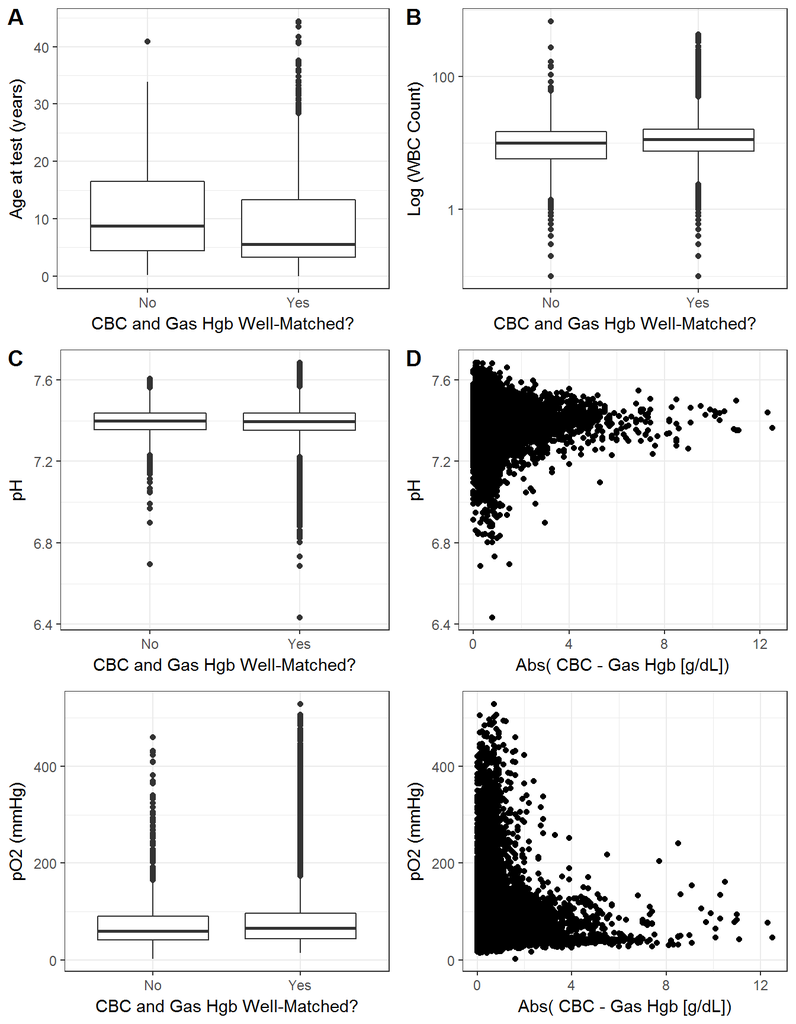

```r
p.age <-
  demo.cbc.gas.match.df %>%
  ggplot() +
  geom_boxplot(aes(x = WELL_MATCHED, y = AGE_AT_TEST)) +
  xlab('CBC and Gas Hgb Well-Matched?') +
  ylab('Age at test (years)') +
  theme_bw()

p.wbc <-
  demo.cbc.gas.match.df %>%
  ggplot() +
  geom_boxplot(aes(x = WELL_MATCHED, y = WBC)) +
  scale_y_log10() +
  xlab('CBC and Gas Hgb Well-Matched?') +
  ylab('Log (WBC Count)') +
  theme_bw()

p.ph.bw <-
  demo.cbc.gas.match.df %>%
  ggplot() +
  geom_boxplot(aes(x = WELL_MATCHED, y = PH)) +
  xlab('CBC and Gas Hgb Well-Matched?') +
  ylab('pH') +
  theme_bw()

p.ph.j <-
  demo.cbc.gas.match.df %>%
  ggplot() +
  geom_point(aes(x = VALUE_ABS_DIFF, y = PH)) +
  xlab('Abs( CBC - Gas Hgb [g/dL])') +
  ylab('pH') +
  theme_bw()

p.po2.bw <-
  demo.cbc.gas.match.df %>%
  ggplot() +
  geom_boxplot(aes(x = WELL_MATCHED, y = PO2)) +
  xlab('CBC and Gas Hgb Well-Matched?') +
  ylab('pO2 (mmHg)') +
  theme_bw()

p.po2.j <-
  demo.cbc.gas.match.df %>%
  ggplot() +
  geom_point(aes(x = VALUE_ABS_DIFF, y = PO2)) +
  xlab('Abs( CBC - Gas Hgb [g/dL])') +
  ylab('pO2 (mmHg)') +
  theme_bw()

plot_grid(p.age, p.wbc,
          p.ph.bw, p.ph.j,
          p.po2.bw, p.po2.j,
          labels = LETTERS[1:4],
          ncol = 2, nrow = 3)
```

#### iStat and CBC Hemoglobins

We now compare the iSTAT and CBC hemoglobin measurements. There are many fewer iStat values then blood gas values, so we will limit to the values with a minimum difference of < 5 minutes between `SPECIMEN_TAKEN_DT`.

```r
hgb.joined <-
  computeJoinedTable(proc.x = c('CBC w Diff', 'CBC wo Diff'),
                     proc.y = c('iStat3', 'iStat7'),
                     base.nm = c('hgb'),
                     suffix = c('.cbc', '.istat'),
                     time.diff = 5)

res.picu <-
  pearsonCalculations(df.joined = hgb.joined,
                      suffix = c('.cbc', '.istat'),
                      dept.grp = c('PICU'),
                      xlab = 'CBC Hemoglobin (g/dL)',
                      ylab = 'iSTAT Hemoglobin (g/dL)',
                      print.res = T)
```

```
## Correlation: R = 0.892
## R^2 = 0.7958
```

```r
res.cicu <-
  pearsonCalculations(df.joined = hgb.joined,
                      suffix = c('.cbc', '.istat'),
                      dept.grp = c('CICU'),
                      xlab = 'CBC Hemoglobin (g/dL)',
                      ylab = 'iSTAT Hemoglobin (g/dL)',
                      print.res = T)
```

```
## Correlation: R = 0.894
## R^2 = 0.8000
```

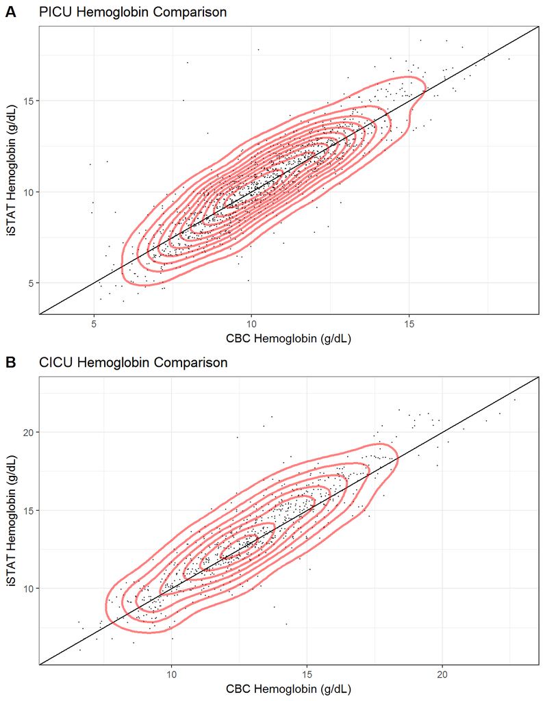

```r
plot_grid(res.picu[[3]] +
            ggtitle('PICU Hemoglobin Comparison') +
            theme_bw(),
          res.cicu[[3]] +
            ggtitle('CICU Hemoglobin Comparison') +
            theme_bw(),
          labels = LETTERS[1:2],
          ncol = 1, nrow = 2)
```

```r
ba.picu <- blandAltmanCalculate(df.joined = hgb.joined,
                                suffix = c('.cbc','.istat'),
                                dept.grp = 'PICU',
                                xlab = 'Average of CBC and iSTAT HGB (g/dL)',
                                ylab = 'Bias [CBC - iSTAT Hgb (g/dL)]',
                                print.res = T)
```

```
## Mean Difference: -0.09
## Confidence Interval: -2.35 to 2.16
```

```r
ba.cicu <- blandAltmanCalculate(df.joined = hgb.joined,
                                suffix = c('.cbc','.istat'),
                                dept.grp = 'CICU',
                                xlab = 'Average of CBC and iSTAT HGB (g/dL)',
                                ylab = 'Bias [CBC - iSTAT Hgb (g/dL)]',
                                print.res = T)
```

```
## Mean Difference: -0.30
## Confidence Interval: -3.07 to 2.46
```

Now plot the Bland Altman plots:

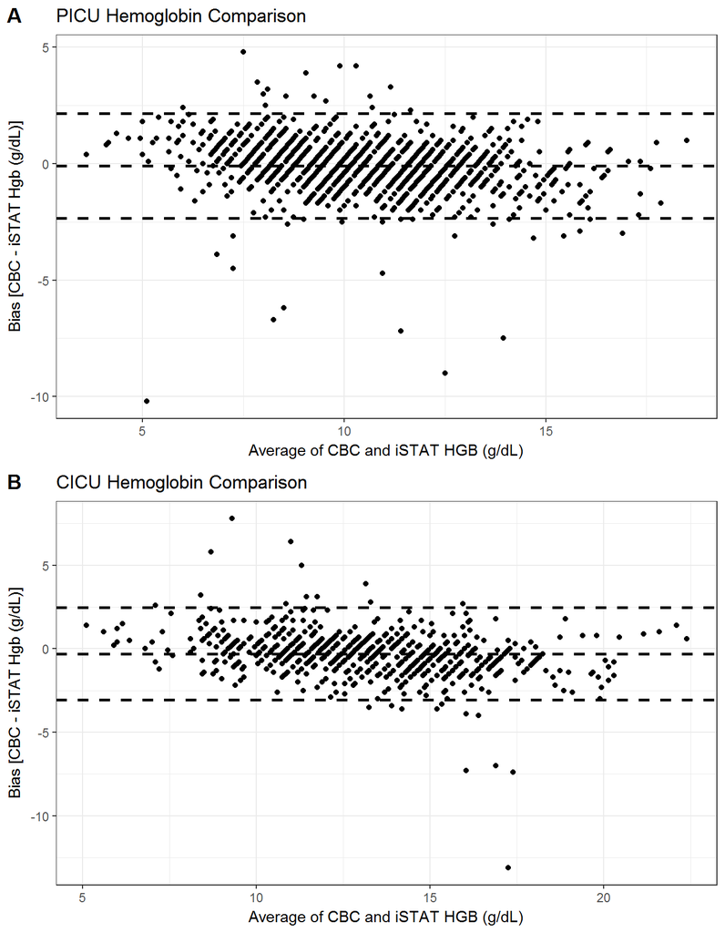

```r
plot_grid(ba.picu[[5]] +
            ggtitle('PICU Hemoglobin Comparison') +
            theme_bw(),
          ba.cicu[[5]] +
            ggtitle('CICU Hemoglobin Comparison') +
            theme_bw(),
          labels = LETTERS[1:2],
          ncol = 1, nrow = 2)
```

Plot a histogram of the difference in `SPECIMEN_TAKEN` date-times - recall that we restricted this difference to an absolute value of < 5 minutes.

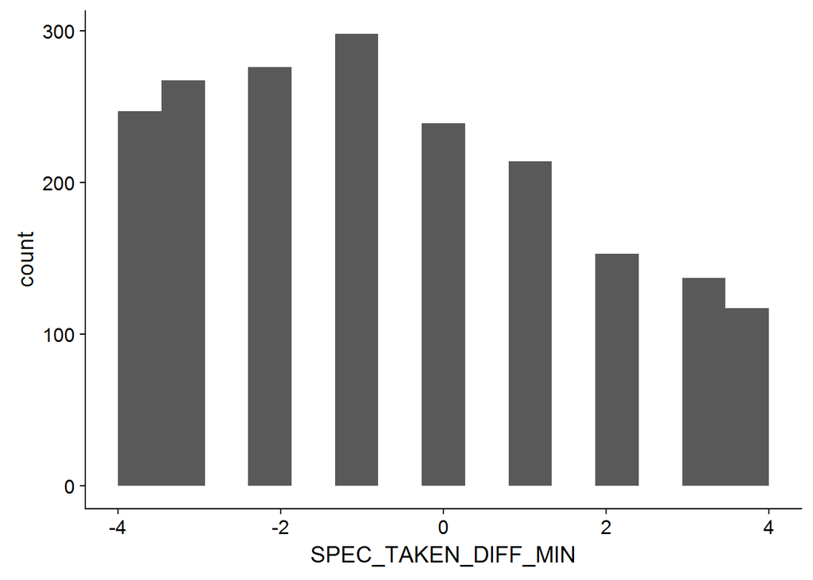

```r
hgb.joined %>%
  ggplot() +
  geom_histogram(aes(x = SPEC_TAKEN_DIFF_MIN), bins = 16)
```

```r
cbc.lt.7 <- hgb.joined$VALUE.cbc <= 7
istat.lt.7 <- hgb.joined$VALUE.istat <= 7

cat(sprintf(paste0('Total rows: %0.f\n',
                   'iStat <= 7 and CBC > 7: %0.f (%0.2f %%)\n',
                   'CBC <= 7 and iStat > 7: %0.f (%0.2f %%)\n'),
            nrow(hgb.joined),
            sum(istat.lt.7 & !cbc.lt.7),
            sum(istat.lt.7 & !cbc.lt.7) / nrow(hgb.joined) * 100,
            sum(cbc.lt.7 & !istat.lt.7),
            sum(cbc.lt.7 & !istat.lt.7) / nrow(hgb.joined) * 100))
```

```
## Total rows: 1948
## iStat <= 7 and CBC > 7: 61 (3.13 %)
## CBC <= 7 and iStat > 7: 23 (1.18 %)
```

Return to Top